# Data Mining

Chibamba Simumba

2023-03-13

# TASK A

We started by installing and loading all the required libraries as seen in the below chunk of code.

```r
library('tm')          # load the tm package for text mining
```

```r
library('SnowballC')   # load the SnowballC package for stemming
library(wordcloud2)    # load the wordcloud2 package for word clouds
library('RColorBrewer')# load the RColorBrewer package for color palettes
library('tidyverse')   # load the tidyverse package for data wrangling
library('tidytext')    # load the tidytext package for text data manipulation
library('topicmodels') # load the topicmodels package for topic modeling
library('lda')         # load the lda package for Latent Dirichlet Allocation modeling
library(wordcloud)
```

## Data Inspection and Familarisation

- We started by loading the data file and there after inspected it to check its content. As it can be seen in the output below the file the dataset had 11 columns and 23,486 rows using the GLIMPSE function, however, for purpose of this analysis we focused on a column called “Review.Text”. We used a function called SELECT to filter only that column with customer reviews for our analysis as see below and inspected the file.

```r
# Reading the dataset
raw_reviews <-read.csv("MS4S09_CW_Data.CSV" )#fileEncoding = "UTF-8"

# Inspecting the content of the file

glimpse(raw_reviews)
```

```
## Rows: 23,486
## Columns: 11
## $ X                       <int> 0, 1, 2, 3, 4, 5, 6, 7, 8, 9, 10, 11, 12, 13, …
## $ Clothing.ID             <int> 767, 1080, 1077, 1049, 847, 1080, 858, 858, 10…
## $ Age                     <int> 33, 34, 60, 50, 47, 49, 39, 39, 24, 34, 53, 39…
## $ Title                   <chr> "", "", "Some major design flaws", "My favorit…
## $ Review.Text             <chr> "Absolutely wonderful - silky and sexy and com…
## $ Rating                  <int> 4, 5, 3, 5, 5, 2, 5, 4, 5, 5, 3, 5, 5, 5, 3, 4…
## $ Recommended.IND         <int> 1, 1, 0, 1, 1, 0, 1, 1, 1, 1, 0, 1, 1, 1, 1, 1…
## $ Positive.Feedback.Count <int> 0, 4, 0, 0, 6, 4, 1, 4, 0, 0, 14, 2, 2, 0, 1, …
## $ Division.Name           <chr> "Initmates", "General", "General", "General Pe…
## $ Department.Name         <chr> "Intimate", "Dresses", "Dresses", "Bottoms", "…
## $ Class.Name              <chr> "Intimates", "Dresses", "Dresses", "Pants", "B…
```

```r
# Keep only the review text column
reviews <- select(raw_reviews, Review.Text,Rating)
glimpse(reviews) # inspecting the customer reviews
```

```
## Rows: 23,486
## Columns: 2
## $ Review.Text <chr> "Absolutely wonderful - silky and sexy and comfortable", "…
## $ Rating      <int> 4, 5, 3, 5, 5, 2, 5, 4, 5, 5, 3, 5, 5, 5, 3, 4, 3, 5, 5, 5…
```

### Initial Observations

- The initial inspection of the text revealed the following thing:
1. Mispelled words, for instance, luv, matvehd, flatttering, pettte, etc.
2. The text content special characters like @, #, /, etc.
3. Inconsistent text case.
4. Stop words.

## TEXT PRE PROCESSING

In this section, we predominately concentrated on text mining pre-processing steps, in other words converting text into semi-structured data to allow us apply analytical techniques. This is a very important step in any text mining project, it was that reason that we spent a considerable amount of time and effort cleaning the dataset to avoid compromising on the quality of results.

This was accomplished using the following steps:

- We first started by removing frequent words that do not contain much information, called stop words, for instance words like “a,” “of,” etc. Additionally, we also created a list of stop words of words we determined to be of little or no value to the analysis.
- Next, we removed all the numbers from the raw data and removed all punctuation from the dataset as they could interfere with our analysis if left unchecked.
- Next, performed a process called tokenisation on the text, which is the processing of splitting text into tokens with a function called UNNEST_TOKENS. This step is important because it will allow us to count and filter individual words during the analysis stage.
- We then removed all non-alphabetic and special characters using the str_replace_all() function .The str_replace_all() function replaces any characters that are not letters with an empty string.
- Further, we proceed to Convert the text to lower case as part of the cleaning and transformation process.
- Additionally, created a custom word replacement to fix all misspelled words in the data file.
- Lastly, we performing a process called stemming on the text, which is the process of reducing words to their root form.

## Text Cleaning and Transformation

```r
# Remove english common stopwords and Tokenize
data(stop_words)

clean_reviews <- reviews %>%

  mutate(Review.Text = gsub("[0-9]+", "", Review.Text)) %>% # remove numbers

  # Tokenize
  unnest_tokens(word, `Review.Text`) %>%

  # Remove english common stopwords
  anti_join(stop_words) %>%

  # Removing all non-alphabetic characters
  mutate(word = str_replace_all(word, "[^[:alpha:]]", "")) %>%
  filter(nchar(word) > 2) %>%

  # Convert the text to lower case
  mutate(word = tolower(word))#%>%
  # stemming
  #mutate(word = stemDocument(word, language = "english"))
```

## Fixing Misspelling and Removing Custom Stop words

- Fixing misspellings, removing custom stop words and other words that determined to be of little or no value to the analysis.
- The cleaning process was repeated several times which indicated that this process is an iterative process.

```r
# define custom stopwords
custom_stopwords <- c("hte", "teh", "aaaaannnnnnd","aaaaandidontwanttopayforshipping", "aaaahs", "oops", "sooo", "lbs", "waas", "grrrrrrrrrrr", "waas", "aaaahs", "aaahed", "aame", "aka", "flo", "difini","to", "buttt", "ttt","wayyy" )

# remove custom stopwords
clean_reviews <- clean_reviews %>%
  filter(!word %in% custom_stopwords)

# replace custom with a new word or character


clean_reviews$word <- gsub("luv", "love", clean_reviews$word)
clean_reviews$word <- gsub("litttle", "little", clean_reviews$word)
clean_reviews$word <- gsub("pettte", "petite", clean_reviews$word)
clean_reviews$word <- gsub("petitethe", "petite", clean_reviews$word)
clean_reviews$word <- gsub("flatttering", "flattering", clean_reviews$word)
clean_reviews$word <- gsub("pattten", "pattern", clean_reviews$word)
clean_reviews$word <- gsub("matvehd", "matched", clean_reviews$word)
clean_reviews$word <- gsub("msallet", "smallest", clean_reviews$word)
clean_reviews$word <- gsub("ejans", "jeans", clean_reviews$word)
clean_reviews$word <- gsub("jkeep", "keep", clean_reviews$word)
clean_reviews$word <- gsub("abck", "back", clean_reviews$word)
clean_reviews$word <- gsub("everythiing", "everything", clean_reviews$word)
clean_reviews$word <- gsub("absolutley", "absolutely", clean_reviews$word)
clean_reviews$word <- gsub("disppointedi", "disappointed", clean_reviews$word)
clean_reviews$word <- gsub("tts", "true to size", clean_reviews$word)
clean_reviews$word <- gsub("absolutly", "absolutely", clean_reviews$word)


# remove custom stopwords
clean_reviews <- clean_reviews %>%
  filter(!word %in% custom_stopwords)%>%

  # stemming
  mutate(word = stemDocument(word, language = "english"))
```

## Customer Reviews Visualizations

- After cleaning and transforming the text, we proceed to inspect and count the clean text to check for the top ten most common words in the customer reviews text using the dplyr’s count function.
- As it can be seen from the below output, DRESS was the most common word in text, followed by the word FIT then LOVE and SIZE.

```r
clean_reviews %>%   # take the data frame 'clean_reviews'
  count(word, sort = TRUE)  # count the frequency of each word, sort in descending order
```

| word | n |
| --- | --- |
| dress | 12174 |
| fit | 11511 |
| love | 11398 |
| size | 10718 |
| top | 8364 |
| wear | 8075 |
| color | 7299 |
| perfect | 5282 |
| fabric | 4890 |
| nice | 3819 |

[output cut: 9020 more lines]

# Plots word frequencies

## Generate the Word cloud

- Now we proceeded the above result in a visual called WordCloud. A WordCloud is a Text mining methods allow us to highlight the most frequently used keywords in texts. Using a WordCloud2 package we visualise the top 2000 most frequent words in the customer reviews text.
- A World Cloud is a representation strategy that shows how words appear in a given body of content as often as possible by measuring each observation relative to its recurrence. All the comments are, at that point, organized in a cluster or cloud of words. The larger the font size of a word, the more frequently it appears.
- As we can see in the below output the word DRESS has the largest font size indicating its high frequent in the text. Followed by the word FIT the LOVE. This appeared to be in line with what was earlier observed from the word count.

```r
clean_reviews %>%   # take the data frame 'clean_reviews'
  count(word, sort = TRUE) %>%   # count the frequency of each word, sort in descending order
  head(2000) %>%   # take the top 2000 most frequent words
  wordcloud2(     # create a word cloud using the wordcloud2 package
    size = 0.8,   # set the size of each word in the cloud
    shape = "heart",   # set the shape of the word cloud to a circle
    color = brewer.pal(8, "Dark2"),   # set the color palette for the words
    backgroundColor = "white",   # set the background color of the word cloud to white
    rotateRatio = 0.5)   # set the rotation ratio for the words in the cloud
```

[interactive chart not shown]

## Generate the Bar Plot

Additionally, the word frequency can also be visualised using a bar plot as seen below. The plot too indicated that words like DRESS, FIT and LOVE topped the list in term count.

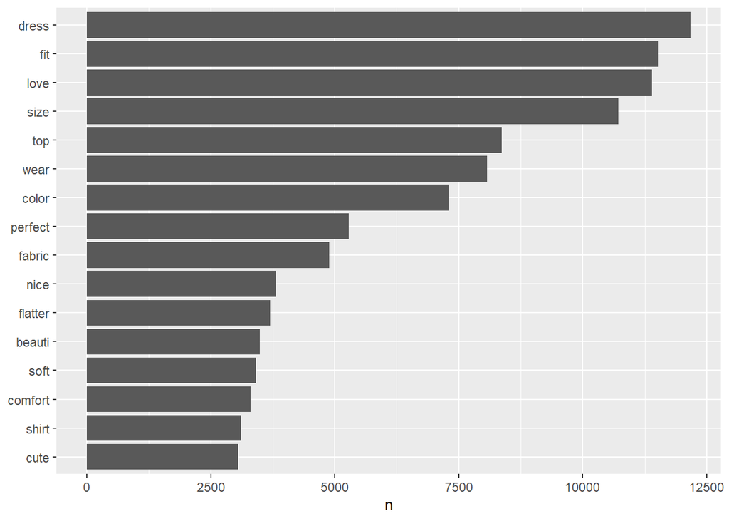

```r
clean_reviews %>%                      # Take the "clean_reviews" data frame and pass it to the next function using the pipe operator (%>%)
  count(word, sort = TRUE) %>%        # Count the frequency of each unique word in the "word" column and sort in descending order
  filter(n > 3000) %>%                # Filter to only include words with a count greater than 3000
  mutate(word = reorder(word, n)) %>% # Reorder the words based on their frequency count
  ggplot(aes(word, n)) +              # Initialize a ggplot object and set the x-axis to the "word" column and y-axis to the "n" column
  geom_col() +                         # Add a column chart to visualize the word frequency
  xlab(NULL) +                         # Remove the x-axis label
  coord_flip()
```

## Genarate WordCloud Per Rating Category

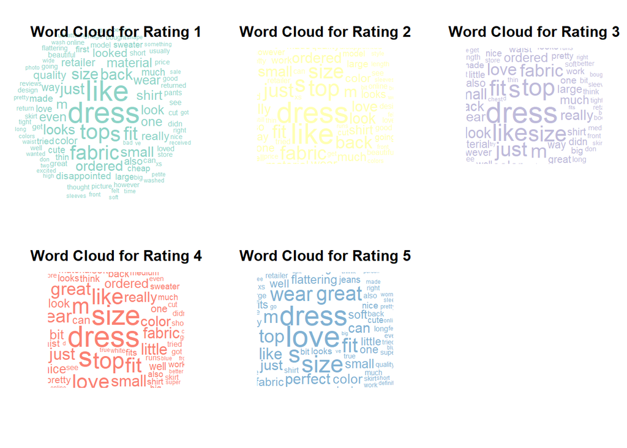

```r
# Create a list of reviews grouped by rating
reviews_list <- split(raw_reviews$Review.Text, raw_reviews$Rating)

# Set up color palette for word clouds
color_palette <- brewer.pal(length(reviews_list), "Set3")

# Define a custom list of stopwords to remove from the text
my_stopwords <- c(stopwords("english"), "will","hte", "teh", "aaaaannnnnnd","aaaaandidontwanttopayforshipping", "aaaahs", "oops", "sooo", "lbs", "waas", "grrrrrrrrrrr", "waas", "aaaahs", "aaahed", "aame", "t")

# Create and plot word clouds for each rating
par(mfrow=c(2,3)) # Set up plot layout
for (i in 1:length(reviews_list)) {
  rating_reviews <- reviews_list[[i]]

  # Remove punctuation, convert to lowercase, and split into words
rating_reviews_clean <- str_replace_all(rating_reviews, "[^[:alnum:]\\s]", " ")
rating_reviews_clean <- str_replace_all(rating_reviews_clean, "\\d+", " ")
rating_reviews_clean <- str_replace_all(rating_reviews_clean, "[[:punct:]]", " ")
rating_reviews_clean <- tolower(rating_reviews_clean)
rating_reviews_clean <- unlist(strsplit(rating_reviews_clean, "\\s+"))

  # Remove stopwords
  rating_reviews_clean <- rating_reviews_clean[!rating_reviews_clean %in% my_stopwords]

  #rating_reviews_clean = stemDocument(rating_reviews_clean, language = "english")

  # Create word frequency table and plot word cloud
  rating_word_freq <- table(rating_reviews_clean)
  rating_wordcloud <- wordcloud(names(rating_word_freq), rating_word_freq,max.words = 100, random.order = FALSE, rot.per = 0, colors = color_palette[i], main = paste0("Rating ", i), scale=c(3,0.2))


  # Add label to word cloud
  title(paste0("Word Cloud for Rating ", i), line = 1, col.main = "black", cex.main = 1.5)}
```

# TASK B

## Sentiment Analysis

In this section we performed explored mined sentiments or opinions from the customer reviews using two lexicons, namely Bing and NRC the compared the results from the two.

## Sentiment Analysis using Bing Lexicon

```r
# For calculating sentiment using Bing Lexicon

clean_reviews %>%   # take the data frame 'clean_reviews'
  inner_join(get_sentiments("bing")) %>%   # join with the sentiment lexicon "bing", keeping only sentiment words
  count(sentiment) %>%   # count the number of positive and negative words
  spread(sentiment, n, fill = 0) %>%   # reshape the data so that it is wide instead of narrow, filling missing values with 0
  mutate(sentiment = positive - negative)   # create a new column called 'sentiment', which is the difference between the number of positive and negative words
```

| negative | positive | sentiment |
| --- | --- | --- |
| 18167 | 59601 | 41434 |

## Inspecting the Sentiments

- Next, we inspected the sentiments by count and arranging them in descending order starting with the highest as seen below.

```r
sent_review <- clean_reviews %>%   # take the data frame 'clean_reviews'
  inner_join(get_sentiments('bing'))   # join with the sentiment lexicon "bing", keeping only sentiment words
sent_review %>%   # take the resulting data frame 'sent_review'
  count(word, sentiment) %>%   # count the number of occurrences of each word with each sentiment
  arrange(desc(n))   # arrange the data frame in descending order by the count of occurrences
```

| word | sentiment | n |
| --- | --- | --- |
| love | positive | 11398 |
| top | positive | 8364 |
| perfect | positive | 5282 |
| nice | positive | 3819 |
| flatter | positive | 3695 |
| soft | positive | 3409 |
| comfort | positive | 3306 |
| cute | positive | 3047 |
| super | positive | 1726 |
| fall | negative | 1533 |

[output cut: 682 more lines]

## Generating Bar Plot for Contribution to Sentiment Using BING Lexicon

- We proceeded to produce visual plots for the earlier stated position of the bing lexicon sentiment analysis results.

```r
bing_sentiments <- clean_reviews %>%   # take the data frame 'clean_reviews'
  inner_join(get_sentiments("bing")) %>%   # join with the sentiment lexicon "bing", keeping only sentiment words
  count(word, sentiment, sort = TRUE) %>%   # count the number of occurrences of each word with each sentiment, and sort by count in descending order
  ungroup()   # remove grouping information from the resulting data frame
bing_sentiments <- clean_reviews %>%
  inner_join(get_sentiments("bing")) %>%
  count(word, sentiment, sort=TRUE)
```

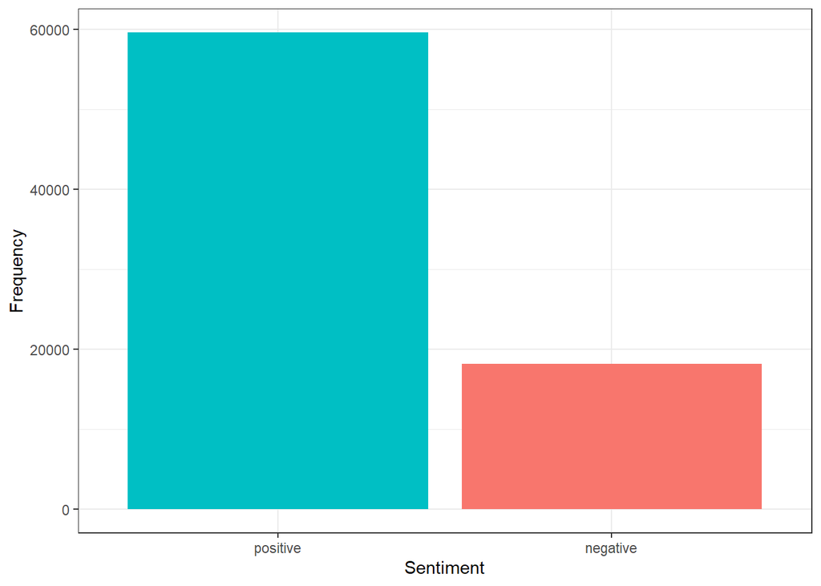

```r
# Plot the Frequency of each sentiment category
ggplot(data=bing_sentiments, aes(x=reorder(sentiment, -n, sum), y=n)) +
  geom_bar(stat="identity", aes(fill=sentiment), show.legend=FALSE) +
  labs(x="Sentiment", y="Frequency") +
  theme_bw()
```

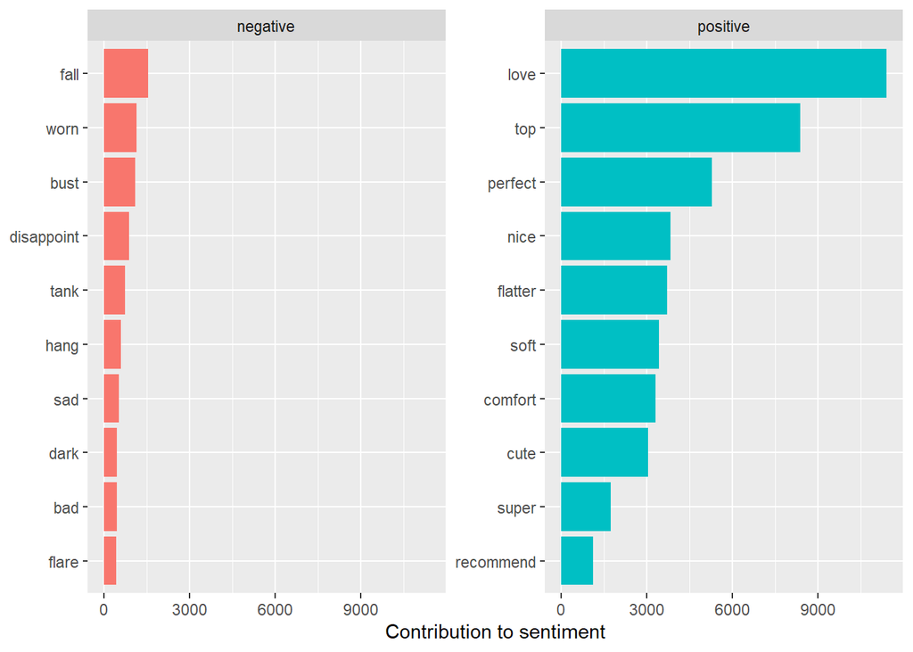

```r
# Top 10 terms for each sentiment

bing_sentiments %>%   # take the resulting data frame 'bing_word_counts'
  group_by(sentiment) %>%   # group the data frame by sentiment
  slice_max(n, n = 10) %>%   # for each sentiment, take the top 10 words with the highest counts
  ungroup() %>%   # remove grouping information from the resulting data frame
  mutate(word = reorder(word, n)) %>%   # reorder the words by count in descending order
  ggplot(aes(n, word, fill = sentiment)) +   # create a ggplot object with the count of words on the x-axis, the words on the y-axis, and the sentiment as the fill color
  geom_col(show.legend = FALSE) +   # add a bar plot layer to the ggplot object
  facet_wrap(~sentiment, scales = "free_y") +   # facet the plot by sentiment, with free y-axis scales
  labs(x = "Contribution to sentiment", y = NULL)   # add x- and y-axis labels to the plot
```

- From the bar plot, we observed that the bing lexicon sentiment results were predominately positive.
- We further plotted the sentiment contribution for Top 10 terms for each sentiment category. The plot was the break down of the sentiments into individual terms or words and, noted that LOVE term was the highest contributor to the positive sentiments. On the other hand, the term FALL was the highest contributor to the negative sentiments, followed by the WORN then BUST.
- This plot too further supported the notion that we had positive sentiment from the customer reviews.

## Postive and Negative WordCloud

- Also created a plot for the most positive and negative words in term of sentiments for the customer reviews. This plot too emphasised the position that we had more positive sentiments than negatives.

```r
library(reshape2)
```

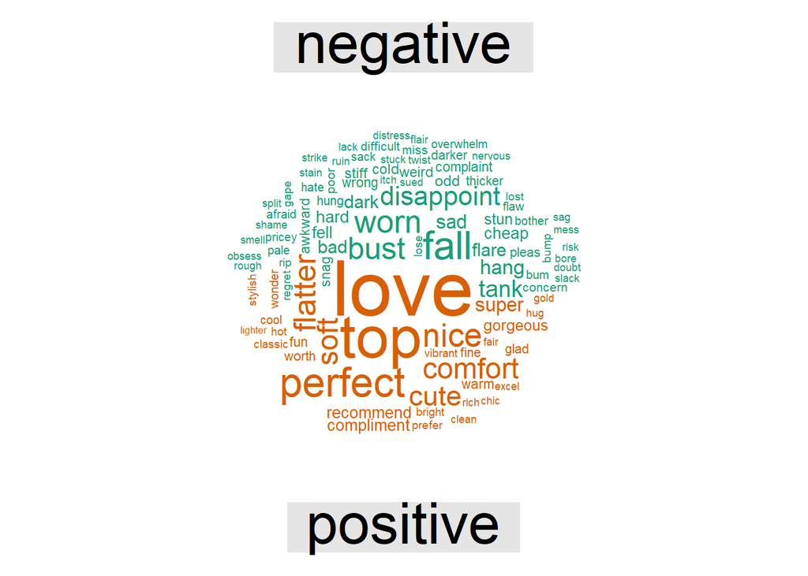

```r
clean_reviews %>%
  inner_join(get_sentiments("bing")) %>%
  count(word, sentiment, sort = TRUE) %>%
  acast(word ~ sentiment, value.var = "n", fill = 0) %>%
  comparison.cloud(colors = brewer.pal(8, "Dark2"),
                   max.words = 100)
```

## Generating Bar Plot for Contribution to Sentiment Using NRC lexicon

- In this section we used the NRC lexicon to perform a sentiment analysis. The NRC lexicon categories words in a binary fashion into categories of positive, negatives, anger, anticipation, disgust, fear, joy, sadness, surprise and trust.

```r
# Use the tidyverse package to join cleaned reviews with NRC sentiment lexicon and count occurrences of each sentiment-word pair

nrc_sentiments <- clean_reviews %>%
  inner_join(get_sentiments("nrc")) %>%
  count(word, sentiment, sort=TRUE)
```

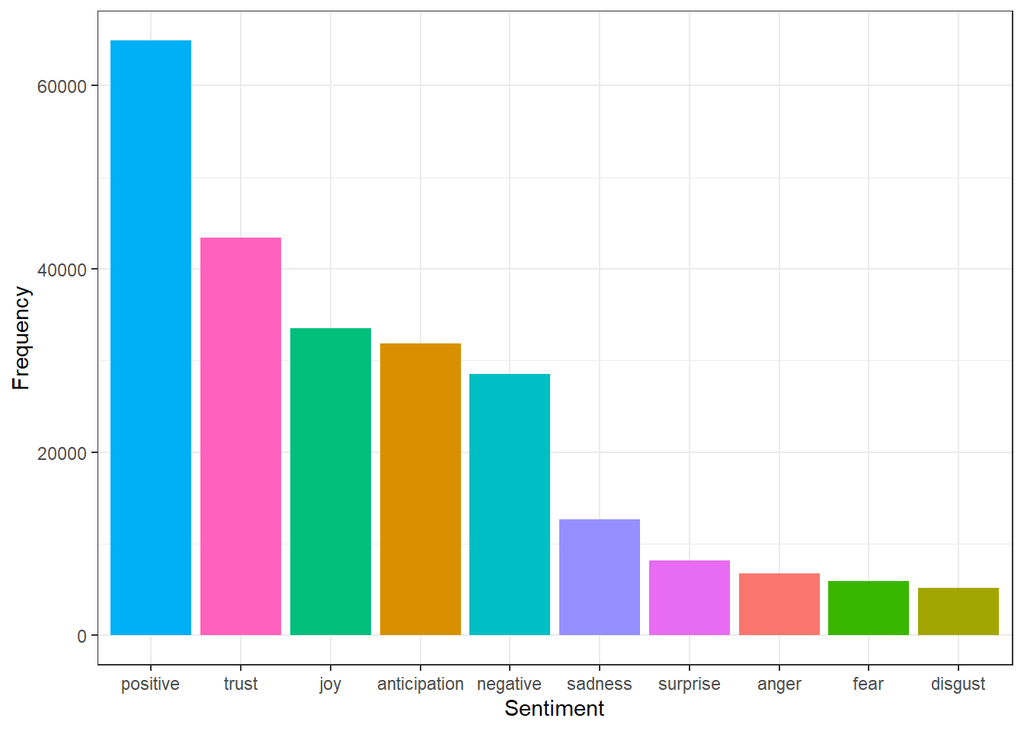

```r
# Create a bar chart showing the frequency of each sentiment category

ggplot(data=nrc_sentiments, aes(x=reorder(sentiment, -n, sum), y=n)) +
  geom_bar(stat="identity", aes(fill=sentiment), show.legend=FALSE) + # create a bar chart with sentiment on x-axis and frequency on y-axis
  labs(x="Sentiment", y="Frequency") + # add x-axis and y-axis labels
  theme_bw() # use a black and white theme
```

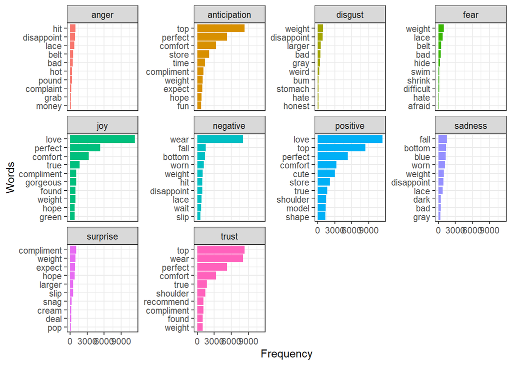

```r
# Create a bar chart showing the top 10 most frequent words for each sentiment category

nrc_sentiments %>%
  group_by(sentiment) %>%
  arrange(desc(n)) %>%
  slice(1:10) %>%
  ggplot(aes(x=reorder(word, n), y=n)) +
  geom_col(aes(fill=sentiment), show.legend=FALSE) + # create a bar chart with words on x-axis and frequency on y-axis
  facet_wrap(~sentiment, scales="free_y") + # facet by sentiment category and free y-axis scales
  labs(y="Frequency", x="Words") + # add x-axis and y-axis labels
  coord_flip() + # flip the chart on its side
  theme_bw() # use a black and white theme
```

- NRC lexicon was also included because we wanted to specifically target reviews with 3 rating which appeared to be in between positive and negative.
- And from the observing the below output, we see that POSITIVE sentiment was the highest followed TRUST, then JOY,ANTICIPATION and NEGATIVE.
- NRC lexicon also suggested that the customers sentiments were positive and of course we others who express anger, disgust and fear.
- The Negative sentiments from the NRC lexicon came from the word WEAR.

# TASK C

## TOPIC MODELLING

### creating the document-term matrix

In this section we explored the customer reviews text data in the hope of understanding some hidden topics. A topic model is a type of statistical model for discovering the abstract “topics” that occur in a collection of documents. In this analysis we used a popular method used to fit topic model called latent Dirichlet allocation, LDA for short. LDA works based on to important principles, it treats each document as a mixture of topics, and each topic as a mixture of words

- We started off by creating creating a document term matrix by first grouping the row number using the groupby() function and word and count the frequency of each word in each document in the Clean_reviews file. We the converted the data frame into a document term matrix using the cast_dtm() function as seen below.

```r
# creating the document-term matrix

# Group by row number and word and count the frequency of each word in each document

dtm <- clean_reviews %>% # take the clean_reviews data frame
  group_by(row_number()) %>% # group the rows by row number
  unnest(word) %>%      # separate each word into a new row
  count(word)           # count the frequency of each word in each document

# Convert the data frame into a document-term matrix

# take the dtm data frame

dtm <- dtm %>%

# convert to a document-term matrix

  cast_dtm(document = row_number(), term = word, value = n)
```

### Model fitting using the LDA

We used the latent Dirichlet allocation method to fit a five-topic model k=5 using the LDA() function from the topic model library. We passed the document term matrix created earlier to the LDA function and set a seed to keep our outputs constant and reproducible.

It is worth mentioning that the initial value of k was purely random and we repeated model fitting process while adjusting the value of k. In our case we settle for the five-topic model as it appeared to be the most optimal value.

- We then inspected the results of the fitted model using a function called term() as seen in the below output.

```r
# set a seed so that the output of the model is predictable
cr_lda <- LDA(dtm,k = 5, control = list(seed = 1234))

#Inspect the LDA Output

terms(cr_lda,5)
```

```
##      Topic 1   Topic 2  Topic 3 Topic 4   Topic 5
## [1,] "love"    "fit"    "size"  "love"    "dress"
## [2,] "wear"    "size"   "dress" "fit"     "top"
## [3,] "top"     "dress"  "wear"  "size"    "fit"
## [4,] "dress"   "fabric" "color" "flatter" "wear"
## [5,] "perfect" "color"  "fit"   "sleev"   "comfort"
```

- After that we then extracted the topic term matrix from the LDA fitted model using the tidytext package as seen in the below output. Basically at this stage we pulled out the betas and grouping them and counting the top ten per topic.Betas are the probabilities of each word being associated with each topic as seen below.
- After that we then visualise the result in bar plots for each topic displaying the words associated to each topic with their betas. See below figures for details.

```r
# Extract topic-term matrix from pre-trained LDA model using tidytext package
cr_topics <- tidy(cr_lda, matrix = "beta")
cr_topics
```

| topic | term | beta |
| --- | --- | --- |
| 1 | absolut | 1.963060e-03 |
| 2 | absolut | 1.060955e-03 |
| 3 | absolut | 8.376441e-04 |
| 4 | absolut | 1.069611e-03 |
| 5 | absolut | 4.566328e-03 |
| 1 | wonder | 7.780769e-04 |
| 2 | wonder | 7.303466e-04 |
| 3 | wonder | 1.845243e-03 |
| 4 | wonder | 8.882277e-04 |
| 5 | wonder | 7.049593e-04 |

[output cut: 9990 more lines]

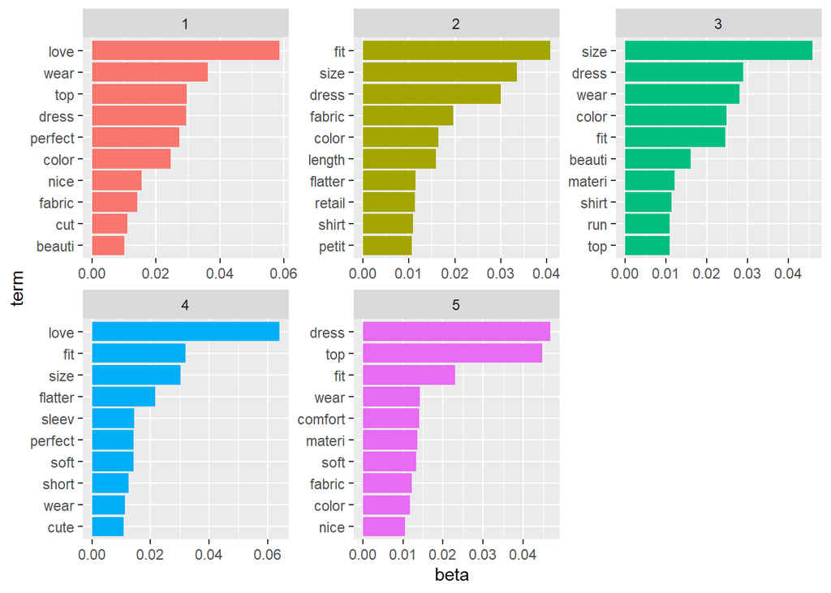

```r
library(ggplot2)
library(dplyr)

# Use the tidyverse package to group the topics and select the top 10 terms with the highest beta value for each topic

cr_top_terms <- cr_topics %>%
  group_by(topic) %>%
  slice_max(beta, n = 10) %>% # select the top 10 terms with the highest beta value for each topic
  ungroup() %>%
  arrange(topic, -beta) # sort by topic and then by decreasing beta value


# Create a bar chart showing the top terms for each topic

cr_top_terms %>%
  mutate(term = reorder_within(term, beta, topic)) %>%
  ggplot(aes(beta, term, fill = factor(topic))) + # create a bar chart with beta value on x-axis, term on y-axis, and color-coded by topic
  geom_col(show.legend = FALSE) + # use the "geom_col" function to create a column chart
  facet_wrap(~ topic, scales = "free") + # facet by topic and allow free y-axis scales
  scale_y_reordered() # reorder the y-axis based on the beta values within each topic
```

## Insights: Topics

- Topic One. Clothing Quality Satisfaction: As seen above, topic one was the combination of general words. This discussion included word like love, wear, top, dress, perfect, color, nice, fabric, cut and beautiful. This discussion appeared to be general, however, the words like love, wear and top had higher probability betas. The words included in this topic are related to positive feeling and satisfaction about clothing.
- Topic Two. General Fit and Size: Fit and Size had the highest probability betas which suggested that they are associated to this particular topic. Words like dress and shirt indicated that the discussion was about different clothing lines or products. And also words like length and petite further supports the notion that this discussion was about size and fit of different clothing product like shirts.
- Topic Three. Clothing Reviews: The word combination for this topic appeared random which suggested that the discussion was about different things like size, dress colour or, fit, shirt and top. After a close inspection of the customer reviews the majority of the words in this topic appeared with the word review. The words size and dress had the highest probability betas further indicated that the discussion were as mostly about the reviews related to size and dresses.
- Topic Four. Clothing Fit and Size Satisfaction: The words included in this topic appeared to be related to positive feeling and satisfaction about clothing fit and size. This is because the word love had the highest probability beta then followed by fit and size. Other words like short, wear, perfect and cute could easily be related to size, fit and positive feeling.
- Topic Five. Dress and Top Fitting: Dress and Top had the highest probability betas followed by Fit. This indicated that the discussion was predominately about how the Dress and Tops fit by the customers. Words like comfort, soft and fabric suggested that the customers were talking about how comfortable and soft the fabric is for the dress and tops.

# TASK D

## LOGISTICS REGRESSION

In this section a used logistics regression to create a classification model that is able to classify whether could recommend the product using variable called Recommended IND as the target using other variable like Age, Rating and Positive Feedback Count as model as predictors.

```r
# Selecting variable of interest from the raw dataset
log_reviews <- raw_reviews %>%
  select(Age, Rating, Recommended.IND, Positive.Feedback.Count)

# Selection Recommended.IND as a Target variable
log_reviews$Recommended.IND <- as.factor(log_reviews$Recommended.IND)

# Clean the data by removing missing values

log_reviews <- na.omit(log_reviews)

# Training and Test sets Split

set.seed(12) # set the random seed for reproducibility
train_idx <- sample(nrow(log_reviews), nrow(log_reviews)*0.7) # randomly select 70% of the rows as the training set
train <- log_reviews[train_idx, ] # subset the training set
test <- log_reviews[-train_idx, ] # subset the test set (the remaining 30%)

# Fit the log_regression model

model <- glm(Recommended.IND ~ Rating + Age + Positive.Feedback.Count, data = train, family = "binomial")


# Predict on the test set
pred <- predict(model, newdata = test, type = "response")
pred <- ifelse(pred > 0.5, 1, 0)

# Evaluate model performance on test set
table(pred, test$Recommended.IND)
```

```
##
## pred    0    1
##    0 1166  330
##    1  149 5401
```

```r
# # Producing a Summary of the model results
summary(model)
```

```
##
## Call:
## glm(formula = Recommended.IND ~ Rating + Age + Positive.Feedback.Count,
##     family = "binomial", data = train)
##
## Deviance Residuals:
##     Min       1Q   Median       3Q      Max
## -3.6636   0.0556   0.0610   0.2724   3.6393
##
## Coefficients:
##                           Estimate Std. Error z value Pr(>|z|)
## (Intercept)             -10.113127   0.259668 -38.946  < 2e-16 ***
## Rating                    3.214457   0.066643  48.234  < 2e-16 ***
## Age                       0.009154   0.003261   2.807 0.005003 **
## Positive.Feedback.Count  -0.019585   0.005648  -3.468 0.000525 ***
## ---
## Signif. codes:  0 '***' 0.001 '**' 0.01 '*' 0.05 '.' 0.1 ' ' 1
##
## (Dispersion parameter for binomial family taken to be 1)
##
##     Null deviance: 15185.1  on 16439  degrees of freedom
## Residual deviance:  4602.8  on 16436  degrees of freedom
## AIC: 4610.8
##
## Number of Fisher Scoring iterations: 7
```

# References

1. ttps://www.howtogeek.com/780627/what-does-tts-mean-and-how-do-you-use-it/#:~:text=TTS%20stands%20for%20”true-to,in%20the%20uppercase%20”TTS.”
2. https://github.com/topics/topic-modeling?l=r
3. https://www.tidytextmining.com/usenet.html
4. https://www.youtube.com/watch?v=m8r7WtZ0voQ&t=1122s
5. https://www.youtube.com/redirect?event=video_description&redir_token=QUFFLUhqbWRma3VMd3ZNbnd2MzAwT3B2NFdyNGU3anRCZ3xBQ3Jtc0ttdHFZ…&q=https%3A%2F%2Fgithub.com%2Fccs-amsterdam%2Fr-course-material%2Fblob%2Fmaster%2Ftutorials%2Fr_text_lda.md&v=4YyoMGv1nkc